# Exploratory Factor Analysis of the Finnish questionnaire

## Info on the project

We have a dataset of responses from a questionnaire about corona taken within a general Finnish population. There are hypothesized **“determinants”** or latent variables that these questions fall under.

To ensure you are measuring these hypothesized latent variables one should perform a **psychometric validation**. In this project, we used the following methods to do so:

- **CFA**
  - Confirmatory Factor Analyis
  - Specify the theoretical structure of the data (subscales + overarching corona variable) and let all questions ‘load’ only on the part of the model that they are supposed to belong to.
  - Ideally, the questions have decent loadings and the model fits well to the data.
- **Measurement invariance**
  - Check whether the above models are the same in different subgroups (e.g. male/female)
- **Internal consistency of the subscales**
  - Cronbach’s alpha
  - Guttman’s lambda_6

See the difference between [CFA and EFA](https://www.theanalysisfactor.com/confirmatory-and-exploratory-factor-analysis/) and the differences between [PCA and EFA](https://www.theanalysisfactor.com/the-fundamental-difference-between-principal-component-analysis-and-factor-analysis/).

Best practice is to use a different dataset for the exploratory part and the confirmatory part. This is not possible here, unless we split the dataset - perhaps we can do this in a follow up.

### Read in the necessary libraries

```r
#load in necessary libraries
library(MASS)
library(vcd) #for assocstats
library(corrplot)
library(psych) #for describe(by)
library(pastecs)
library(qgraph)
library(semPlot) # for semPath
# library(gdata) # for read.xls
library(lavaan) # for cfa, sem, lavaan etc
library(semTools)
library(Hmisc) #for rcorr

source(file = "validation_utils.R")
```

### Read in the data

```r
df <- read.csv("data/taloustutkimus_james.csv")
# code_df <- read.csv2("data/questions_and_categories.csv")[c("Variable.name", "Label", "Type")]
code_df <- read.csv2("data/questions_and_categories_V2.csv")#[c("Variable.name", "Label", "Type")]
```

```r
df[df==""] <- NA
sapply(df, class)
```

```
                        ID             PT10_SUKUPUOLI                     PT_AGE                PT_MAAKUNTA                PT_SUURALUE
                 "integer"                  "integer"                "character"                  "integer"                  "integer"
       PT_ASUINPAIKKAKUNTA              PT60_KOULUTUS               PT80_AMMATTI    PT90_TALOUDEN_ELINVAIHE        PT110_TALOUDEN_KOKO
                 "integer"                  "integer"                  "integer"                  "integer"                  "integer"
PT120_TALOUDEN_BRUTTOTULOT       PT200_ASUNNON_TYYPPI                         Q1                         Q2                         Q4
               "character"                  "integer"                  "integer"                  "integer"                  "integer"
                        Q5                       Q6_1                       Q6_2                       Q6_3                       Q6_4
                 "integer"                  "integer"                  "integer"                  "integer"                  "integer"
                      Q6_5                       Q6_6                       Q6_7                      Q6_SO                         Q7
                 "integer"                  "integer"                  "integer"                "character"                  "integer"
                      Q8_1                       Q8_2                       Q8_3                       Q8_4                       Q8_5
                 "integer"                  "integer"                  "integer"                  "integer"                  "integer"
                     Q13_1                      Q14_1                        Q15                      Q16_1                      Q17_1
                 "integer"                  "integer"                  "integer"                  "integer"                  "integer"
                     Q18_1                      Q19_1                      Q20_1                      Q21_1                      Q21_2
                 "integer"                  "integer"                  "integer"                  "integer"                  "integer"
                     Q21_3                      Q21_4                      Q25_1                      Q26_1                      Q27_1
                 "integer"                  "integer"                  "integer"                  "integer"                  "integer"
                     Q28_1                      Q29_1                      Q30_1                      Q30_2                      Q30_3
                 "integer"                  "integer"                  "integer"                  "integer"                  "integer"
                     Q30_4                      Q30_5                      Q30_6                      Q30_7                      Q30_8
                 "integer"                  "integer"                  "integer"                  "integer"                  "integer"
                     Q30_9                     Q30_10                     Q30_11                     Q30_12                     Q30_13
                 "integer"                  "integer"                  "integer"                  "integer"                  "integer"
                    Q30_14                     Q30_15                      Q31_1                      Q31_2                      Q31_3
                 "integer"                  "integer"                  "integer"                  "integer"                  "integer"
                     Q31_4                      Q35_1                      Q36_1                      Q37_1                      Q38_1
                 "integer"                  "integer"                  "integer"                  "integer"                  "integer"
                     Q39_1                      Q40_1                      Q41_1                      Q42_1                      Q42_2
                 "integer"                  "integer"                  "integer"                  "integer"                  "integer"
                     Q42_3                      Q42_4                      Q42_5                      Q42_6                      Q48_1
                 "integer"                  "integer"                  "integer"                  "integer"                  "integer"
                     Q48_2                      Q48_3                      Q48_4                      Q48_5                      Q48_6
                 "integer"                  "integer"                  "integer"                  "integer"                  "integer"
                     Q48_7                      Q48_8                      Q48_9                     Q48_10                     Q48_11
                 "integer"                  "integer"                  "integer"                  "integer"                  "integer"
                    Q48_12                     Q48_13                      Q61_1                        Q62                        Q63
                 "integer"                  "integer"                  "integer"                  "integer"                  "integer"
                       Q64                        Q65                        Q66                      Q68_1                      Q68_2
                 "integer"                  "integer"                  "integer"                  "integer"                  "integer"
                     Q68_3             kotilasten_iat
                 "integer"                "character"
```

```r
# transform(df, Q6_SO = as.numeric(Q6_SO))
```

```r
feature_names_list <- code_df[code_df["Type"] != "demographic" & code_df["Of.primary.interest.as.a.predictor..i.e..feature.."] != "no", "Variable.name"]
feature_names_list <- feature_names_list[feature_names_list != "Q6_SO" & feature_names_list !="kotilasten_iat"]
```

### Show Correlations between the questions

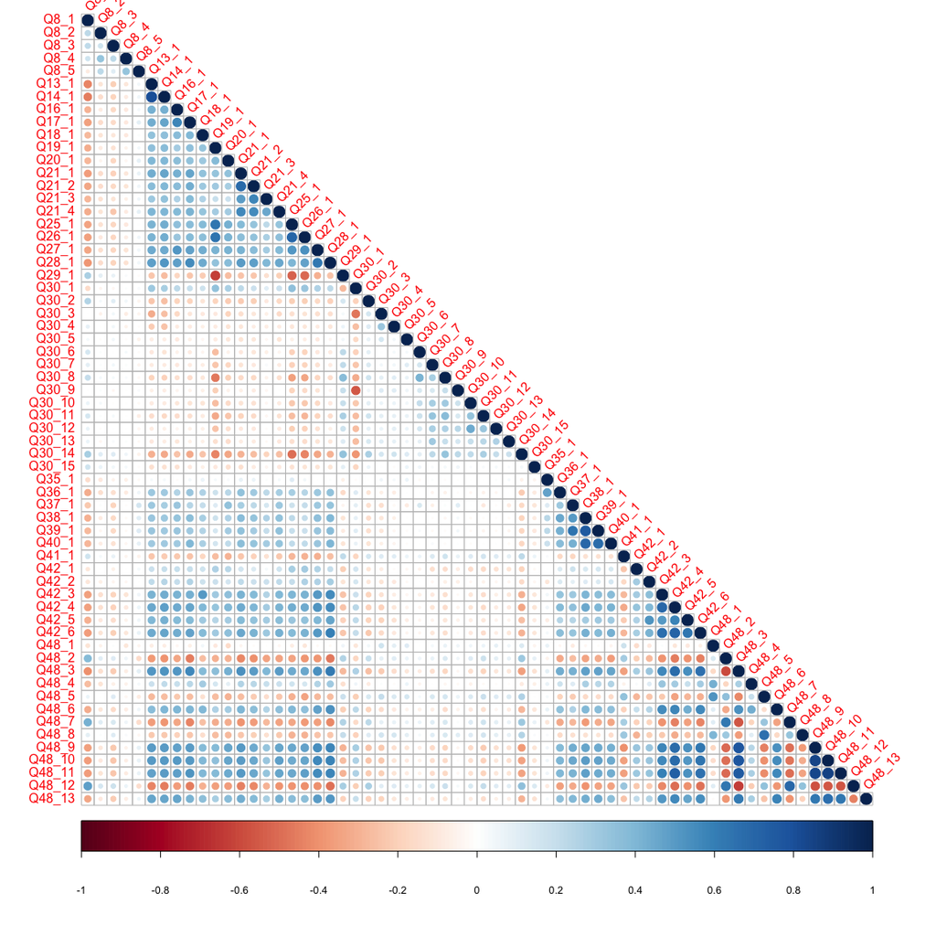

```r
corrplot(cor(df[feature_names_list], method="spearman"),
         type="lower", tl.srt=45, sig.level=0.01,insig = "blank")
```

```r
#PCA and EFA specific preconditional analyses====
#conduct bartlett test - test of whether variables in a matrix are correlated (i.e,
#whether the correlation matrix is an identity matrix), the result should be
#significant at p < .05. (only ran on Neuro data)
cat('BARTLETT:'); cortest.bartlett(df[feature_names_list], n = nrow(df), diag = TRUE) #Yay $p.value = 0
```

```
BARTLETT:
```

```
R was not square, finding R from data
```

```
$chisq
[1] 77549.41

$p.value
[1] 0

$df
[1] 1891
```

```r
#KMO test output - KMO test is a statistic that is a measure of the proportion of variance
#among variables that might be common variance. This value should be greater than 0.5.
cat('KMO:'); kmo(df[feature_names_list])$overall #overall is 0.94 so we good
```

```
KMO:[1] 0.9590225
```

```r
#Calculate the value of the determinant - The determinant is an indicator of multicollinearity -
#a measure of the overall relation between the variables, which should be greater than 0.00001
#for the data to be used in factor analysis.
cat('DETERMINANT:'); det(cor(df[feature_names_list], method='spearman')) #determinant is 1.014526e-11 - consider removing highly correlated variables - e.g.
```

```
DETERMINANT:[1] 1.795494e-14
```

```r
#check correlation matrix df
cors <- data.frame(cor(df[feature_names_list], method='spearman'))
```

##CFA

For every CFA, a model syntax is provided. The model is fit according to this model, and the goodness of fit is evaluated by several measures.

- cfi (comparitive fit index) should be > 0.95 (or > 0.90)
- rmsea (root mean squared error of approximation) should be < 0.05 (or < 0.08)
- srmr (standardized root mean square residual) should be < 0.05 (or < 0.08)
- gfi (goodness of fit index) should be > 0.90 (or > 0.95)

```r
# code_df[code_df["Type"] != "demographic", c("Variable.name", "Type")]
dplyr::filter(code_df, Variable.name %in% feature_names_list)[c("Variable.name", "Type")]
```

| Variable.name | Type |
| --- | --- |
| Q8_1 | intention |
| Q8_2 | intention |
| Q8_3 | intention |
| Q8_4 | intention |
| Q8_5 | intention |
| Q13_1 | automaticity |
| Q14_1 | automaticity |
| Q16_1 | instrumental_attitude |
| Q17_1 | instrumental_attitude |
| Q18_1 | instrumental_attitude |

[output cut: 52 more lines]

```r
NA
```

```r
feature_names_list
```

```
 [1] "Q8_1"   "Q8_2"   "Q8_3"   "Q8_4"   "Q8_5"   "Q13_1"  "Q14_1"  "Q16_1"  "Q17_1"  "Q18_1"  "Q19_1"  "Q20_1"  "Q21_1"  "Q21_2"  "Q21_3"  "Q21_4"  "Q25_1"
[18] "Q26_1"  "Q27_1"  "Q28_1"  "Q29_1"  "Q30_1"  "Q30_2"  "Q30_3"  "Q30_4"  "Q30_5"  "Q30_6"  "Q30_7"  "Q30_8"  "Q30_9"  "Q30_10" "Q30_11" "Q30_12" "Q30_13"
[35] "Q30_14" "Q30_15" "Q35_1"  "Q36_1"  "Q37_1"  "Q38_1"  "Q39_1"  "Q40_1"  "Q41_1"  "Q42_1"  "Q42_2"  "Q42_3"  "Q42_4"  "Q42_5"  "Q42_6"  "Q48_1"  "Q48_2"
[52] "Q48_3"  "Q48_4"  "Q48_5"  "Q48_6"  "Q48_7"  "Q48_8"  "Q48_9"  "Q48_10" "Q48_11" "Q48_12" "Q48_13"
```

```r
paste(unlist(code_df[code_df["Type"] == "barriers", "Variable.name"]), collapse=" + ")
```

```
[1] "Q30_1 + Q30_2 + Q30_3 + Q30_4 + Q30_5 + Q30_6 + Q30_7 + Q30_8 + Q30_9 + Q30_10 + Q30_11 + Q30_12 + Q30_13 + Q30_14 + Q30_15"
```

```r
# Models for the entire population ========================================================
#### four subscales (without questions that were not correlated to other items, without sleep)
theo_model <- '
# behaviour =~  Q1 + Q2 + Q4 + Q5
# mask_wearing =~ Q6_1 + Q6_2 + Q6_3 + Q6_4 + Q6_5 + Q6_6 + Q6_7 + Q7
intention =~ Q8_1 + Q8_2 + Q8_3 + Q8_4 + Q8_5
automaticity =~ Q13_1 + Q14_1
instrumental_attitude =~ Q16_1 + Q17_1 + Q18_1 + Q19_1 + Q20_1
norms =~ Q21_1 + Q21_2 + Q21_3 + Q21_4
affective_attitude =~ Q25_1 + Q26_1 + Q27_1 + Q28_1 + Q29_1
barriers =~ Q30_1 + Q30_2 + Q30_3 + Q30_4 + Q30_5 + Q30_6 + Q30_7 + Q30_8 + Q30_9 + Q30_10 + Q30_11 + Q30_12 + Q30_13 + Q30_14 + Q30_15
# vaccines =~ Q31_1 + Q31_2 + Q31_3 + Q31_4
perceived_risk =~ Q35_1 + Q36_1 + Q37_1 + Q38_1 + Q39_1 + Q40_1 + Q41_1
sdt_needs =~ Q42_1 + Q42_2 + Q42_3 + Q42_4 + Q42_5 + Q42_6
sdt_motivation =~ Q48_1 + Q48_2 + Q48_3 + Q48_4 + Q48_5 + Q48_6 + Q48_7 + Q48_8 + Q48_9 + Q48_10 + Q48_11 + Q48_12 + Q48_13

overall_corona =~ intention + automaticity + instrumental_attitude + norms + affective_attitude + barriers + perceived_risk + sdt_needs + sdt_motivation

# overall_corona =~ behaviour + intention + automaticity + instrumental_attitude + norms + affective_attitude + barriers + vaccines + perceived_risk + sdt_needs + sdt_motivation

'
```

```r
fit_theo <- cfa(theo_model, data=df,
                           #group = 'Version',
                    std.lv = TRUE,
                    orthogonal = F,
                    control = list(rel.tol=1e-9, iter.max=1e6),
                    verbose=FALSE)
summary(fit_theo, standardized = T, fit.measures=TRUE)
```

```
lavaan 0.6-7 ended normally after 142 iterations

  Estimator                                         ML
  Optimization method                           NLMINB
  Number of free parameters                        133

  Number of observations                          2272

Model Test User Model:

  Test statistic                              19971.901
  Degrees of freedom                               1820
  P-value (Chi-square)                            0.000

Model Test Baseline Model:

  Test statistic                             78325.074
  Degrees of freedom                              1891
  P-value                                        0.000

User Model versus Baseline Model:

  Comparative Fit Index (CFI)                    0.763
  Tucker-Lewis Index (TLI)                       0.753

Loglikelihood and Information Criteria:

  Loglikelihood user model (H0)            -172534.261
  Loglikelihood unrestricted model (H1)    -162548.311

  Akaike (AIC)                              345334.523
  Bayesian (BIC)                            346096.402
  Sample-size adjusted Bayesian (BIC)       345673.838

Root Mean Square Error of Approximation:

  RMSEA                                          0.066
  90 Percent confidence interval - lower         0.065
  90 Percent confidence interval - upper         0.067
  P-value RMSEA <= 0.05                          0.000
```

[output cut: 154 more lines]

```
   .Q48_9             0.614    0.022   27.819    0.000    0.614    0.183
   .Q48_10            0.617    0.022   27.770    0.000    0.617    0.182
   .Q48_11            0.590    0.021   27.604    0.000    0.590    0.178
   .Q48_12            0.834    0.026   32.037    0.000    0.834    0.439
   .Q48_13            1.602    0.050   32.254    0.000    1.602    0.473
   .intention         1.000                               0.456    0.456
   .automaticity      1.000                               0.385    0.385
   .instrmntl_tttd    1.000                               0.087    0.087
   .norms             1.000                               0.396    0.396
   .affective_tttd    1.000                               0.191    0.191
   .barriers          1.000                               0.745    0.745
   .perceived_risk    1.000                               0.564    0.564
   .sdt_needs         1.000                               0.225    0.225
   .sdt_motivation    1.000                               0.150    0.150
    overall_corona    1.000                               1.000    1.000
```

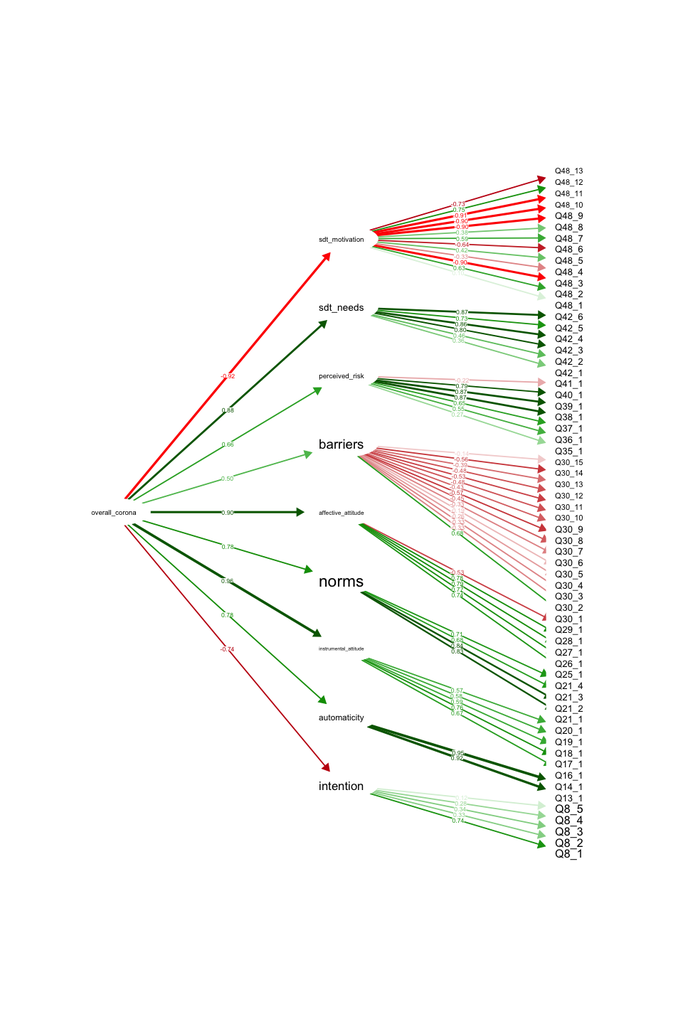

```r
#Plot the model
semPaths(fit_theo, what= "std", layout = "tree", rotation = 2,
         nCharNodes = 0,intercepts = F, residuals = F, edge.label.cex = 0.3,
         sizeLat2 = 3, sizeMan2 = 2, borders=F, label.cex=0.8,
         # edge.label.position = rep(c(0.6,0.7),100)[1:90],
         # edge.label.position = rep(c(0.6,0.7),300)[1:23],
         width = 10, label.scale=T, #posCol=neurocolours[3], negCol=neurocolours[6],
         maximum=1.25, thresholds=F)
```

```r
try(check_cfa(fit_theo, show_mod_ind = F))
```

```
Goodness of fit:
       cfi      rmsea       srmr        gfi
0.76251559 0.06625539 0.07699610 0.71461078
```

```r
fit_theo_factor_loadings_df <- data.frame(inspect(fit_theo,what="std")$lambda)
fit_theo_factor_loadings_df
```

|  | intention | automaticity | instrumental_attitude | norms | affective_attitude | barriers | perceived_risk | sdt_needs | sdt_motivation | overall_corona |
| --- | --- | --- | --- | --- | --- | --- | --- | --- | --- | --- |
| Q8_1 | 0.7357792 | 0.0000000 | 0.0000000 | 0.0000000 | 0.0000000 | 0.0000000 | 0.0000000 | 0.0000000 | 0.0000000 | 0 |
| Q8_2 | 0.3331183 | 0.0000000 | 0.0000000 | 0.0000000 | 0.0000000 | 0.0000000 | 0.0000000 | 0.0000000 | 0.0000000 | 0 |
| Q8_3 | 0.3426257 | 0.0000000 | 0.0000000 | 0.0000000 | 0.0000000 | 0.0000000 | 0.0000000 | 0.0000000 | 0.0000000 | 0 |
| Q8_4 | 0.2782780 | 0.0000000 | 0.0000000 | 0.0000000 | 0.0000000 | 0.0000000 | 0.0000000 | 0.0000000 | 0.0000000 | 0 |
| Q8_5 | 0.1185793 | 0.0000000 | 0.0000000 | 0.0000000 | 0.0000000 | 0.0000000 | 0.0000000 | 0.0000000 | 0.0000000 | 0 |
| Q13_1 | 0.0000000 | 0.9218236 | 0.0000000 | 0.0000000 | 0.0000000 | 0.0000000 | 0.0000000 | 0.0000000 | 0.0000000 | 0 |
| Q14_1 | 0.0000000 | 0.9531200 | 0.0000000 | 0.0000000 | 0.0000000 | 0.0000000 | 0.0000000 | 0.0000000 | 0.0000000 | 0 |
| Q16_1 | 0.0000000 | 0.0000000 | 0.6721095 | 0.0000000 | 0.0000000 | 0.0000000 | 0.0000000 | 0.0000000 | 0.0000000 | 0 |
| Q17_1 | 0.0000000 | 0.0000000 | 0.7567874 | 0.0000000 | 0.0000000 | 0.0000000 | 0.0000000 | 0.0000000 | 0.0000000 | 0 |
| Q18_1 | 0.0000000 | 0.0000000 | 0.5922499 | 0.0000000 | 0.0000000 | 0.0000000 | 0.0000000 | 0.0000000 | 0.0000000 | 0 |

[output cut: 52 more lines]

```r
write.csv(fit_theo_factor_loadings_df, "data/factor_loadings_V2.csv")
```